# 2016 US Presidential Campaign Finance in Nevada

### Plot Two

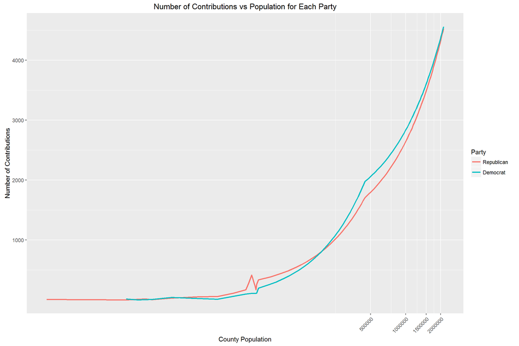

### Plot Three

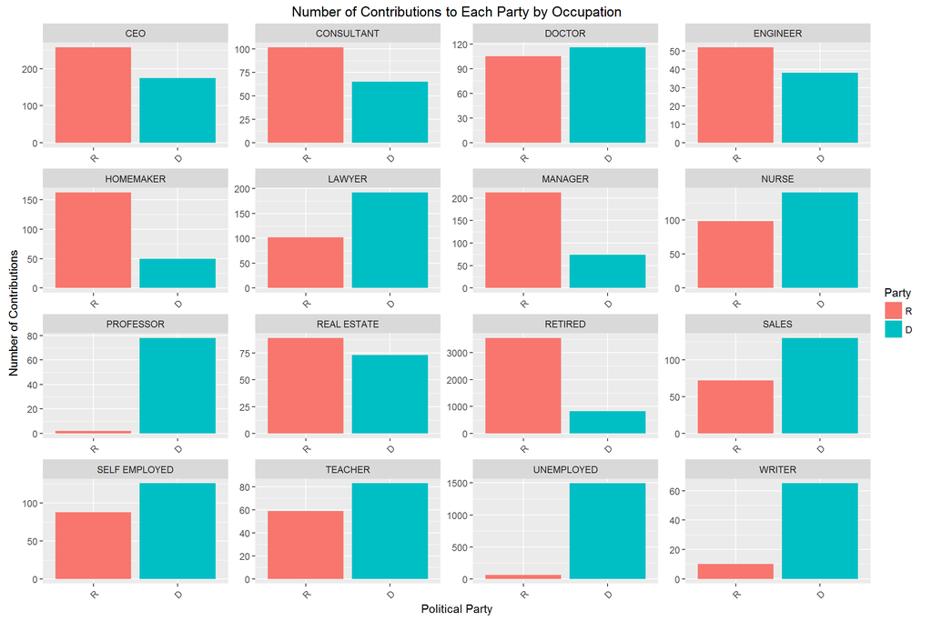

### Description Three

This is a plot of number of contributions to each party based on contributor occupation. It is interesting to see that some occupations overwhelmingly lean toward one party or another, while others have a relatively even split. This only represents data for known occupations with at least 75 contributions. There were over 1000 different occupations in the dataset overall, so it would have been impractical to try to plot them all.

# Reflection

I started off the analysis by looking at contribution amounts and numbers, and as soon as I got to the bivariate section, I felt mostly at a loss, so I decided to add more data. This took several iterations and a lot of testing and data wrangling before I got the data that I wanted in the form that I wanted. In fact, I think I probably spent much more time on this part of the project than on the actual data analysis. I suppose this is in line with [the work that most data scientists do](http://www.nytimes.com/2014/08/18/technology/for-big-data-scientists-hurdle-to-insights-is-janitor-work.html?_r=0), though.

There were also certain areas that were much less interesting than I thought they would be. Contributions over time, for example, didn’t really show anything other than what you would expect: as the election gets closer, contributions increase. With contribution amount vs median income, I was expecting a strong correlation, but instead saw a very weak correlation. But, I suppose that it is just as important (if not more so) to find out which of your assumptions were wrong as it is to find and confirm the ones that were correct.

The plot that had the biggest impact on my own view was the second plot in the final plots section. I made the plot just as a way to view contributions vs population for each party, but I wasn’t expecting to see anything interesting at all. Instead, I saw where the lines crossed over each other, showing that places with higher populations tended to contribute one way, while places with lower populations tended to contribute the other way. I think that this sort of unexpected realization is at the core of why exploratory data analysis is important–sometimes the most meaningful relationships come out where you least expect them to.

Future work that could be performed on this data set could be to take a look at the numbers for each party leading up to each presidential election. For example, for this election, the Republicans have a higher number contributions and a higher total amount of contributions in Nevada compared to the Democrats, but what did the numbers look like in 2004, 2008, and 2012? Also, for the few candidates that run in multiple election years, it would be interesting to see if they did any better the second time around. Along these same lines, it would also be interesting to see if different occupations support different parties in different elections or if they tend to stick to the same parties.

Overall, I felt that I learned a lot in the Exploratory Data Analysis course and this project. I learned that sometimes doing something that seems like it should be quick and simple (like adding more data to what you already have) can end up being the most laborious step in the whole process. Most importantly, I also learned that data exploration is very helpful in testing your assumptions and helping you to see connections that you wouldn’t even have thought to look for.

# Sources

- Main dataset from the [Federal Election Commission](http://fec.gov/disclosurep/pnational.do) - *Click on “Export Contributor Data” and then “NV.zip” (click on “File Format” for data description)*
- Additional data taken from the [US Census Bureau website](http://factfinder.census.gov/faces/nav/jsf/pages/download_center.xhtml)
- Information on how to convert the month MMM string variable to an integer: StackOverflow - *[convert mmm to numeric in R](http://stackoverflow.com/questions/6549239/convert-mmm-to-numeric-in-r)*
- [How to plot factors in a specified order in ggplot](http://rstudio-pubs-static.s3.amazonaws.com/7433_4537ea5073dc4162950abb715f513469.html)
- Shapefiles for maps from the [US Census Bureau](http://www.census.gov/cgi-bin/geo/shapefiles2010/main) website.
- Instructions for how to use the shapefiles: StackOverflow - *[Plotting color map with zip codes in R or Python](http://stackoverflow.com/questions/1441717/plotting-color-map-with-zip-codes-in-r-or-python)*
- And the heatmap function by [Eduardo Leoni](http://stackoverflow.com/users/143377/eduardo-leoni) to go with the shapefiles: StackOverflow - *[Developing Geographi Thematic Maps with R](http://stackoverflow.com/questions/1260965/developing-geographic-thematic-maps-with-r)*
- [Renaming columns in a data frame](http://www.cookbook-r.com/Manipulating_data/Renaming_columns_in_a_data_frame/)
- For Python script to parse Wikipedia table: StackOverflow - *[python BeautifulSoup parsing table](http://stackoverflow.com/questions/23377533/python-beautifulsoup-parsing-table)*
- Table used to get county names for cities in Nevada: Wikipedia - *[List of cities in Nevada](https://en.wikipedia.org/wiki/List_of_cities_in_Nevada)*